# Pandas - General

## Pandas

- Python Data Analysis Library
- originally written by Wes McKinney
- creates a Python object with rows and columns called data frame

## Loading and Saving Data with Pandas

- convert a Python’s list, dictionary or Numpy array to a Pandas data frame
- open a local file using Pandas, usually a CSV file, but could also be a delimited text file (like TSV), Excel, etc
- open a remote file or database like a CSV or a JSONon a website through a URL or read from a SQL table/database
- what about SPSS files:
  - convert them to csv or excel
  - use savReaderWriter module

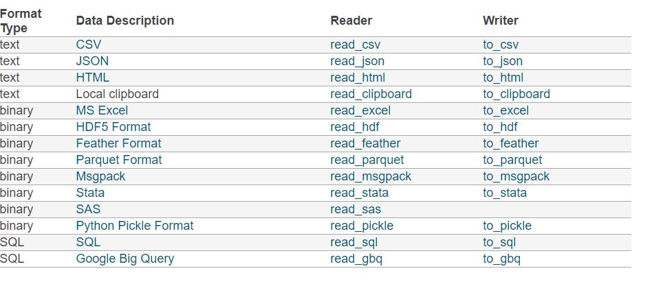

## Loading and Saving Data with Pandas

- importing from excel

```python
import pandas as pd
import numpy as np
data=pd.read_excel("./Lab/Datasets/cars.xlsx")
print(data.head())
```

```
##    Year  Month Manufacturer              Model  Quantity
## 0  2007      1  Volkswagen   Volkswagen Passat      1267
## 1  2007      1      Toyota         Toyota Rav4       819
## 2  2007      1      Toyota      Toyota Avensis       787
## 3  2007      1  Volkswagen     Volkswagen Golf       720
## 4  2007      1      Toyota      Toyota Corolla       691
```

## Writing data

- df.to_filetype(filename)

```python
data.to_csv("./Lab/Datasets/CarsCSV.csv")
```

## Lab

Take Master.csv file, import it and export only 10 rows to excel file called Master10.xlsx.

## Basic exploratory commands

- df.head(n): n first rows
- df.tail(n): n last rows
- df.shape: the number of rows and columns
- df.info(): the index, datatype and memory information
- s.value_counts(dropna=False): would allow you to view unique values and counts for a series
- df.describe(): summary statistics for numerical columns
- df.corr(): correlation between columns in a data frame

## Lab

Take master.csv file and answer: - How many unique weight values are present in DF? - How many rows and columns does the DF have? - How much memory does DF use? - Perform summary statistics for numerical columns. What is the mean and std of the height column? - What is the correlation between hright and weight?

## Subsetting

- df[col]: return column with label col as Series
- df[[col1, col2]]: returns columns as a new DataFram
- df.iloc[0,:]: selecting first row
- df.iloc[0,0]: selecting the first element of the first column

## Lab

- Print the second row of the master DF
- Print from the 10th row till 20th row (included)
- Print weight and height columns
- Print the 4th row of the weight and height columns
- Print the 10th element of the weight column

## Filter, sort and groupby

- df[df[column] > value]: all rows where column is greater than value
- &: and ; |: or; df[**(**df[column1] > value1**)** & **(**df[column2<value2]**)**]
- df.sort_values(column1): sorting DF by column1 ASC (default)
- df.sort_values(column2,ascending=False): sorting DF by column1 DESC
- df.sort_values([column1,column2],ascending=[True,False]): sorting by 2 columns
- df.groupby(column): involves splitting the data into groups based on some criteria, applying a function to each group independently and combining the results into a data structure
- df.groupby([column1,column2])

## Renaming

- df.rename()
- (index=index_mapper, columns=columns_mapper, …)
- df.rename(index=str, {columns={“A”: “a”, “B”: “c”})
- (mapper, axis={‘index’, ‘columns’}, …)
- df.rename({“A”: “a”, “C”: “c”}, axis=‘columns’)
- df.rename(columns={“A”: “a”, “C”: “c”})

## Lab

Calculate players’ mean height and mean weight by birthState for players, who were born in USA after 1950. Print only birthState, mean height and weight sorted by birthState DESC. HINT: df.mean() returns mean for all columns. Rename columns to State, AverageW and AverageH.

## Data Cleaning (1)

- pd.isnull(): checking for null values
- df[df.column.isnull()]: returns DF with rows, where column has null values
- pd.isnull().sum(): how many null values
- df.dropna(): drop missing values (rows) (axis=1 columns)
- df.fillna(x): replace missing values with x
- s.fillna(s.mean()): replace missing values with the mean
- df.column.fillna(df.column.mean(), inplace=True): replacing null values in column with mean of this column and saving the result immediately (inplace=True)

## Lab

Show 10 rows of Master DF, where weight is null. Replace null values in weight column with average. Print the average value and the 20th row from Master DF.

## Data Cleaning (2)

- advanced manipulation with missing values: interpolate()
- works on numerical data
- linear, time, index, values, nearest, zero, slinear, quadratic, cubic, barycentric, krogh, polynomial,…

```
##       A     B     C     D
## 0  12.0   NaN  20.0  14.0
## 1   4.0   2.0  16.0   3.0
## 2   5.0  54.0   NaN   NaN
## 3   NaN   3.0   3.0   NaN
## 4   1.0   NaN   8.0   6.0
```

```python
print(df.interpolate(method="linear"))
```

```
##       A     B     C     D
## 0  12.0   NaN  20.0  14.0
## 1   4.0   2.0  16.0   3.0
## 2   5.0  54.0   9.5   4.0
## 3   3.0   3.0   3.0   5.0
## 4   1.0   3.0   8.0   6.0
```

## Lab

Show 10 rows of Master DF, where height is null. Remember indexes of the first 2 rows. Use linear and cubic interpolation. Show 2 rows that you remembered.

## Data Cleaning (3)

- s.replace(1,‘one’): replacing 1 with one
- s.replace([1,3],[‘one’,‘three’]): replacing 1 with one and 3 with three
- s.replace([1,3],[‘one’]): replacing 1 and 3 with one

## Calculated columns

- df[calculated_column]=df[column1]+df[column2]: new column is the sum of two existing columns
- df[calculated_column]=df.column1*df.column2: new column is the product of two existing columns
- df[calculated_column]=pow(df.column1, 2): new column is the power of two of the column1

## Lab

Take birthCountry, height and weight from the Master DF. Apply linear interpolation to height and cubic to weight. Calculate: - tranform weight from pounds to kg and height from inches to meters - BMI: show 10 rows - average BMI index by bithCoutry, sort by birthCountry

## Pivoting

- df.pivot_table(data, values=None, index=None, columns=None, aggfunc=‘mean’, fill_value=None, margins=False, dropna=True, margins_name=‘All’)

```
##      A    B      C  D  E
## 0  foo  one  small  1  2
## 1  foo  one  large  2  4
## 2  foo  one  large  2  5
## 3  foo  two  small  3  5
## 4  foo  two  small  3  6
## 5  bar  one  large  4  6
## 6  bar  one  small  5  8
## 7  bar  two  small  6  9
## 8  bar  two  large  7  9
```

## Pivoting

```python
table = pd.pivot_table(df, values='D', index=['A', 'B'],
                   columns=['C'], aggfunc=np.sum)
print(table)
```

```
## C        large  small
## A   B
## bar one    4.0    5.0
##     two    7.0    6.0
## foo one    4.0    1.0
##     two    NaN    6.0
```

```python
table = pd.pivot_table(df, values=['D', 'E'], index=['A', 'C'],
                         aggfunc={'D': np.mean,
                              'E': [min, max, np.mean]})
print(table)
```

```
##                   D    E
##                mean  max      mean  min
## A   C
## bar large  5.500000  9.0  7.500000  6.0
##     small  5.500000  9.0  8.500000  8.0
## foo large  2.000000  5.0  4.500000  4.0
##     small  2.333333  6.0  4.333333  2.0
```

## Lab

Take Master DF and keep only rows where birthYear 1954, 1955 and 1956. Show mean, max and min of height and weight by months and by birthYear.